# Decision+Tree+-Random+Forest-+GBM

```python
import os
import numpy as np
import pandas as pd

from sklearn import tree
```

```python
# Using Decision tree as a non-paramteric method to create heuristic rules for classification and regression
```

```python
#benefits of using a decision tree
#1. simple to understand and interpret the results
#2. Tree structure, which represents the rules can be visualized
#3. less data manipulation, transformation or normalization
#4. less costly algorithm
#5. handle both numerical and categorical data
#6. multinomial problem: multiclass can be handles easily
#7. validate the model easily
```

```python
-(.38)*np.log2(0.38)+(-(0.62)*np.log2(0.62)) #base entropy 0.95
```

```
0.9580420222262995
```

```python
np.log2(1.0)
```

```
0.0
```

```python
#for branch where emabrek = C
-(.55)*np.log2(0.55)+(-(0.45)*np.log2(0.45))
#for branch where emabrek = S
-(.43)*np.log2(0.43)+(-(0.57)*np.log2(0.57))
#for branch where emabrek = Q
-(.43)*np.log2(0.43)+(-(0.57)*np.log2(0.57))
#for branch where emabrek = B
0
weithed_entropy = ((168/884)*(-(.55)*np.log2(0.55)+(-(0.45)*np.log2(0.45)))) + ((70/884) * (-(.43)*np.log2(0.43)+(-(0.57)*np.log2(0.57)))) + ((644/884)*(-(.43)*np.log2(0.43)+(-(0.57)*np.log2(0.57))))
weithed_entropy
```

```
0.9849072905154983
```

```python
F1= 0.2
F2 = -0.2
F3 = 0.4
```

```python
# Maximum variance
# Gini Coefficient
# Entropy
```

```python
Informaion_gain = (-(.38)*np.log2(0.38)+(-(0.62)*np.log2(0.62))) - weithed_entropy
Informaion_gain
```

```
-0.026865268289198774
```

```python
-(.333)*np.log2(0.333)+(-(0.333)*np.log2(0.333))+(-(0.333)*np.log2(0.333)) #base entropy
```

```
1.584819511673234
```

```python
# How to decide, which variable to be placed at the root node
# Ans: compare the information gain by putting each variable at the root node
# the variable that gives maximum information gain need to be selected

# Information Gain = Entropy at base - Weighted Entropy at the node after the split

# How to select the brances

# How long you can expand the decision tree (max_depth)
# Ans:
# conditions to stop the decision tree
# if all the samples in a node belong to same class
# if all the features are already part of the tree
# if all the samples entered the tree model


# what is stopping criteria to terminate a tree
# if all the samples in a node belong to same class
# if all the features are already part of the tree
# if all the samples entered the tree model

# if i expand the tree, what are the limitations
# model ovefit, train accuracy will be different from test accuracy

# how to identify right fit for the tree
# a balance between train and test

# how to prune the tree
# put conditions, min sample, max_depth, min leaf, delta chnage in IG

# validation of a tree
# k-fold cross validation can be used to prune the decision tree
```

```python
from sklearn.datasets import load_iris
iris = load_iris()
```

```python
iris.target
```

```
array([0, 0, 0, 0, 0, 0, 0, 0, 0, 0, 0, 0, 0, 0, 0, 0, 0, 0, 0, 0, 0, 0, 0,
       0, 0, 0, 0, 0, 0, 0, 0, 0, 0, 0, 0, 0, 0, 0, 0, 0, 0, 0, 0, 0, 0, 0,
       0, 0, 0, 0, 1, 1, 1, 1, 1, 1, 1, 1, 1, 1, 1, 1, 1, 1, 1, 1, 1, 1, 1,
       1, 1, 1, 1, 1, 1, 1, 1, 1, 1, 1, 1, 1, 1, 1, 1, 1, 1, 1, 1, 1, 1, 1,
       1, 1, 1, 1, 1, 1, 1, 1, 2, 2, 2, 2, 2, 2, 2, 2, 2, 2, 2, 2, 2, 2, 2,
       2, 2, 2, 2, 2, 2, 2, 2, 2, 2, 2, 2, 2, 2, 2, 2, 2, 2, 2, 2, 2, 2, 2,
       2, 2, 2, 2, 2, 2, 2, 2, 2, 2, 2, 2])
```

```python
print (iris.DESCR)
```

```
Iris Plants Database
====================

Notes
-----
Data Set Characteristics:
    :Number of Instances: 150 (50 in each of three classes)
    :Number of Attributes: 4 numeric, predictive attributes and the class
    :Attribute Information:
        - sepal length in cm
        - sepal width in cm
        - petal length in cm
        - petal width in cm
        - class:
                - Iris-Setosa
                - Iris-Versicolour
                - Iris-Virginica
    :Summary Statistics:

    ============== ==== ==== ======= ===== ====================
                    Min  Max   Mean    SD   Class Correlation
    ============== ==== ==== ======= ===== ====================
    sepal length:   4.3  7.9   5.84   0.83    0.7826
    sepal width:    2.0  4.4   3.05   0.43   -0.4194
    petal length:   1.0  6.9   3.76   1.76    0.9490  (high!)
    petal width:    0.1  2.5   1.20  0.76     0.9565  (high!)
    ============== ==== ==== ======= ===== ====================

    :Missing Attribute Values: None
    :Class Distribution: 33.3% for each of 3 classes.
    :Creator: R.A. Fisher
    :Donor: Michael Marshall (MARSHALL%PLU@io.arc.nasa.gov)
    :Date: July, 1988

This is a copy of UCI ML iris datasets.
http://archive.ics.uci.edu/ml/datasets/Iris

The famous Iris database, first used by Sir R.A Fisher

This is perhaps the best known database to be found in the
pattern recognition literature.  Fisher's paper is a classic in the field and
is referenced frequently to this day.  (See Duda & Hart, for example.)  The
data set contains 3 classes of 50 instances each, where each class refers to a
type of iris plant.  One class is linearly separable from the other 2; the
latter are NOT linearly separable from each other.

References
----------
   - Fisher,R.A. "The use of multiple measurements in taxonomic problems"
     Annual Eugenics, 7, Part II, 179-188 (1936); also in "Contributions to
     Mathematical Statistics" (John Wiley, NY, 1950).
   - Duda,R.O., & Hart,P.E. (1973) Pattern Classification and Scene Analysis.
     (Q327.D83) John Wiley & Sons.  ISBN 0-471-22361-1.  See page 218.
   - Dasarathy, B.V. (1980) "Nosing Around the Neighborhood: A New System
     Structure and Classification Rule for Recognition in Partially Exposed
     Environments".  IEEE Transactions on Pattern Analysis and Machine
     Intelligence, Vol. PAMI-2, No. 1, 67-71.
   - Gates, G.W. (1972) "The Reduced Nearest Neighbor Rule".  IEEE Transactions
     on Information Theory, May 1972, 431-433.
   - See also: 1988 MLC Proceedings, 54-64.  Cheeseman et al"s AUTOCLASS II
     conceptual clustering system finds 3 classes in the data.
   - Many, many more ...
```

```python
tree.DecisionTreeClassifier() # tree initializations
```

```
DecisionTreeClassifier(class_weight=None, criterion='gini', max_depth=None,
            max_features=None, max_leaf_nodes=None,
            min_impurity_decrease=0.0, min_impurity_split=None,
            min_samples_leaf=1, min_samples_split=2,
            min_weight_fraction_leaf=0.0, presort=False, random_state=None,
            splitter='best')
```

```python
tree1 = tree.DecisionTreeClassifier()
tree1.fit(iris.data,iris.target)
```

```
DecisionTreeClassifier(class_weight=None, criterion='gini', max_depth=None,
            max_features=None, max_leaf_nodes=None,
            min_impurity_decrease=0.0, min_impurity_split=None,
            min_samples_leaf=1, min_samples_split=2,
            min_weight_fraction_leaf=0.0, presort=False, random_state=None,
            splitter='best')
```

```python
tree1.score(iris.data,iris.target)
```

```
1.0
```

```python
iris.feature_names
```

```
['sepal length (cm)',
 'sepal width (cm)',
 'petal length (cm)',
 'petal width (cm)']
```

```python
tree1.feature_importances_
```

```
array([ 0.        ,  0.01333333,  0.06405596,  0.92261071])
```

```python
13/40
```

```
0.325
```

```python
#tree pruning conditions

#1. if all the samples in a leaf node belong to one specific class
#2. if all the samples absorbed in the model
#3. if all the variables are entered into the model
```

```python
# classification criteria

#1. Gini Impurity Index : Sum(Pmk*(1-Pmk))
# m = 3 (Iris Dataset)
# 1,2,3.......K-1 number of levels in a target variable
# k= number of samples for each class
```

```python
#2. Cross Entropy: Sum(-Pmk*log(Pmk))
# m = 3 (Iris Dataset)
# 1,2,3.......K-1 number of levels in a target variable
# k= number of samples for each class
```

```python
#3. Misclassification Approach: 1-max(Pmk)
# m = 3 (Iris Dataset)
# 1,2,3.......K-1 number of levels in a target variable
# k= number of samples for each class
```

```python
# n = 150
# Setosa = 50
# P(setosa,samples) = 50/150
```

```python
df = pd.read_csv('https://archive.ics.uci.edu/ml/machine-learning-databases/wine/wine.data',header=None,sep=',')
```

```python
df.head()
```

|  | 0 | 1 | 2 | 3 | 4 | 5 | 6 | 7 | 8 | 9 | 10 | 11 | 12 | 13 |
| --- | --- | --- | --- | --- | --- | --- | --- | --- | --- | --- | --- | --- | --- | --- |
| 0 | 1 | 14.23 | 1.71 | 2.43 | 15.6 | 127 | 2.80 | 3.06 | 0.28 | 2.29 | 5.64 | 1.04 | 3.92 | 1065 |
| 1 | 1 | 13.20 | 1.78 | 2.14 | 11.2 | 100 | 2.65 | 2.76 | 0.26 | 1.28 | 4.38 | 1.05 | 3.40 | 1050 |
| 2 | 1 | 13.16 | 2.36 | 2.67 | 18.6 | 101 | 2.80 | 3.24 | 0.30 | 2.81 | 5.68 | 1.03 | 3.17 | 1185 |
| 3 | 1 | 14.37 | 1.95 | 2.50 | 16.8 | 113 | 3.85 | 3.49 | 0.24 | 2.18 | 7.80 | 0.86 | 3.45 | 1480 |
| 4 | 1 | 13.24 | 2.59 | 2.87 | 21.0 | 118 | 2.80 | 2.69 | 0.39 | 1.82 | 4.32 | 1.04 | 2.93 | 735 |

```python
df.columns = ['Target','Alcohol','Malic acid','Ash','Alcalinity of ash ','Magnesium',' Total phenols',
             'Flavanoids','Nonflavanoid phenols','Proanthocyanins','Color intensity','Hue','diluted wines','Proline']
```

```python
df.head()
```

|  | Target | Alcohol | Malic acid | Ash | Alcalinity of ash | Magnesium | Total phenols | Flavanoids | Nonflavanoid phenols | Proanthocyanins | Color intensity | Hue | diluted wines | Proline |
| --- | --- | --- | --- | --- | --- | --- | --- | --- | --- | --- | --- | --- | --- | --- |
| 0 | 1 | 14.23 | 1.71 | 2.43 | 15.6 | 127 | 2.80 | 3.06 | 0.28 | 2.29 | 5.64 | 1.04 | 3.92 | 1065 |
| 1 | 1 | 13.20 | 1.78 | 2.14 | 11.2 | 100 | 2.65 | 2.76 | 0.26 | 1.28 | 4.38 | 1.05 | 3.40 | 1050 |
| 2 | 1 | 13.16 | 2.36 | 2.67 | 18.6 | 101 | 2.80 | 3.24 | 0.30 | 2.81 | 5.68 | 1.03 | 3.17 | 1185 |
| 3 | 1 | 14.37 | 1.95 | 2.50 | 16.8 | 113 | 3.85 | 3.49 | 0.24 | 2.18 | 7.80 | 0.86 | 3.45 | 1480 |
| 4 | 1 | 13.24 | 2.59 | 2.87 | 21.0 | 118 | 2.80 | 2.69 | 0.39 | 1.82 | 4.32 | 1.04 | 2.93 | 735 |

1) Alcohol 2) Malic acid 3) Ash 4) Alcalinity of ash  
5) Magnesium 6) Total phenols 7) Flavanoids 8) Nonflavanoid phenols 9) Proanthocyanins 10)Color intensity 11)Hue 12)OD280/OD315 of diluted wines 13)Proline

```python
from sklearn.datasets import load_iris
from sklearn import tree
```

```python
iris = load_iris()
```

```python
iris.data.shape # input data
```

```
(150, 4)
```

```python
#print iris.DESCR
```

```python
iris.feature_names # getting the feature names
```

```
['sepal length (cm)',
 'sepal width (cm)',
 'petal length (cm)',
 'petal width (cm)']
```

```python
iris.target.shape # target variable or dependent variable
```

```
(150,)
```

```python
mytree = tree.DecisionTreeClassifier()
mytree
```

```
DecisionTreeClassifier(class_weight=None, criterion='gini', max_depth=None,
            max_features=None, max_leaf_nodes=None,
            min_impurity_decrease=0.0, min_impurity_split=None,
            min_samples_leaf=1, min_samples_split=2,
            min_weight_fraction_leaf=0.0, presort=False, random_state=None,
            splitter='best')
```

```python
mytree = tree.DecisionTreeClassifier(criterion='entropy')
mytree
```

```
DecisionTreeClassifier(class_weight=None, criterion='entropy', max_depth=None,
            max_features=None, max_leaf_nodes=None,
            min_impurity_decrease=0.0, min_impurity_split=None,
            min_samples_leaf=1, min_samples_split=2,
            min_weight_fraction_leaf=0.0, presort=False, random_state=None,
            splitter='best')
```

```python
dt1 = mytree.fit(iris.data, iris.target)
dt1
```

```
DecisionTreeClassifier(class_weight=None, criterion='entropy', max_depth=None,
            max_features=None, max_leaf_nodes=None,
            min_impurity_decrease=0.0, min_impurity_split=None,
            min_samples_leaf=1, min_samples_split=2,
            min_weight_fraction_leaf=0.0, presort=False, random_state=None,
            splitter='best')
```

```python
dt1.feature_importances_
```

```
array([ 0.        ,  0.0115876 ,  0.07765342,  0.91075898])
```

```python
dt1.fit(iris.data, iris.target)
tree.export_graphviz(dt1,out_file='None')
```

```python
tree.export_graphviz(dt1,out_file='tree.dot')
dotfile = open("tree.dot", 'w')
tree.export_graphviz(dt1, out_file = dotfile, feature_names = iris.feature_names)
dotfile.close()
```

```python
dot_d = tree.export_graphviz(dt1,out_file='Decision Tree')
```

```python
from sklearn.datasets import load_iris
from sklearn import tree
iris = load_iris()
clf = tree.DecisionTreeClassifier()
clf = clf.fit(iris.data, iris.target)
```

```python
with open("iris.dot", 'w') as f:
    f = tree.export_graphviz(clf, out_file=f)
```

```python
import os
```

```python
os.unlink('iris.dot')
```

```python
from IPython.display import Image
```

```python
print(dot_d)
```

```
None
```

```python
dot_data = tree.export_graphviz(clf, out_file='Decision Tree',
                         feature_names=iris.feature_names,
                         class_names=iris.target_names,
                         filled=True, rounded=True,
                         special_characters=True)
```

```python
graph = pydotplus.graph_from_dot_data(dot_data)
graph
```

[output not shown]

```python
import pydotplus
```

[output not shown]

```python
!pip install pydotplus
```

[output not shown]

[output not shown]

```python
!pip install msgpack
```

[output not shown]

```python
# three methods determine the importance of features
# 1. mean decrease in gini coefficient
# 2. informtion gain -cross entropy
# 3. variance based approach
```

```python
dt1.score(iris.data,iris.target)
```

```
1.0
```

```python
# decision tree for regression based problems
from sklearn.datasets import load_boston
from sklearn.cross_validation import cross_val_score
from sklearn.tree import DecisionTreeRegressor
```

```
E:\New folder\lib\site-packages\sklearn\cross_validation.py:41: DeprecationWarning: This module was deprecated in version 0.18 in favor of the model_selection module into which all the refactored classes and functions are moved. Also note that the interface of the new CV iterators are different from…
  "This module will be removed in 0.20.", DeprecationWarning)
```

```python
boston = load_boston()
regressor = DecisionTreeRegressor(random_state=0)
```

```python
from sklearn.cross_validation import train_test_split
```

```python
X_train,X_test,Y_train,Y_test = train_test_split(boston.data, boston.target,test_size=0.20,random_state=1234)
```

```python
X_train.shape,Y_train.shape,X_test.shape,Y_test.shape
```

```
((404, 13), (404,), (102, 13), (102,))
```

```python
regressor.fit(X_train,Y_train)
```

```
DecisionTreeRegressor(criterion='mse', max_depth=None, max_features=None,
           max_leaf_nodes=None, min_impurity_decrease=0.0,
           min_impurity_split=None, min_samples_leaf=1,
           min_samples_split=2, min_weight_fraction_leaf=0.0,
           presort=False, random_state=0, splitter='best')
```

```python
help(DecisionTreeRegressor())
```

[output not shown]

[output cut: 251 more lines]

[output not shown]

```python
regressor.score(X_train,Y_train) #training accuracy
```

```
1.0
```

```python
regressor.score(X_test,Y_test) #test accuracy
```

```
0.86370913459890819
```

```python
from sklearn.model_selection import GridSearchCV
from time import time
from operator import itemgetter
```

```python
# create a function to perform grid search with cross validation and returns the accuracy values
def GridSearch_BestParam(X, y, clf, param_grid,cv=10):
    grid_search = GridSearchCV(clf,
                              param_grid=param_grid,
                              cv=cv)
    start= time()
    grid_search.fit(X,y)
    top_params=grid_search.grid_scores_
    return top_params
```

```python
param_grid = {"criterion": ["mae","mse","friedman_mse"],
             "min_samples_split": [2,10,20],
             "max_depth": [2,5,10],
             "min_samples_leaf":[1,2,10]}
```

```python
cvDT = tree.DecisionTreeRegressor()
```

```python
top_para = GridSearch_BestParam(X_train,Y_train, cvDT, param_grid, cv=10)
print (top_para)
```

```
[mean: 0.62226, std: 0.11260, params: {'criterion': 'mae', 'max_depth': 2, 'min_samples_leaf': 1, 'min_samples_split': 2}, mean: 0.62226, std: 0.11260, params: {'criterion': 'mae', 'max_depth': 2, 'min_samples_leaf': 1, 'min_samples_split': 10}, mean: 0.62226, std: 0.11260, params: {'criterion': 'ma…
```

```
E:\New folder\lib\site-packages\sklearn\model_selection\_search.py:761: DeprecationWarning: The grid_scores_ attribute was deprecated in version 0.18 in favor of the more elaborate cv_results_ attribute. The grid_scores_ attribute will not be available from 0.20
  DeprecationWarning)
```

```python
top_score = sorted(top_para,key=itemgetter(1), reverse=True)
top_score
```

```
[mean: 0.80950, std: 0.07237, params: {'criterion': 'mae', 'max_depth': 10, 'min_samples_leaf': 1, 'min_samples_split': 20},
 mean: 0.80526, std: 0.07934, params: {'criterion': 'mae', 'max_depth': 10, 'min_samples_leaf': 1, 'min_samples_split': 10},
 mean: 0.79891, std: 0.07894, params: {'criterion': 'mae', 'max_depth': 10, 'min_samples_leaf': 2, 'min_samples_split': 20},
 mean: 0.79354, std: 0.06389, params: {'criterion': 'mae', 'max_depth': 5, 'min_samples_leaf': 1, 'min_samples_split': 10},
 mean: 0.79348, std: 0.05585, params: {'criterion': 'mse', 'max_depth': 10, 'min_samples_leaf': 2, 'min_samples_split': 20},
 mean: 0.79226, std: 0.05961, params: {'criterion': 'friedman_mse', 'max_depth': 10, 'min_samples_leaf': 2, 'min_samples_split': 20},
 mean: 0.78951, std: 0.04717, params: {'criterion': 'mse', 'max_depth': 10, 'min_samples_leaf': 1, 'min_samples_split': 20},
 mean: 0.78729, std: 0.07841, params: {'criterion': 'mae', 'max_depth': 10, 'min_samples_leaf': 2, 'min_samples_split': 10},
 mean: 0.78235, std: 0.04871, params: {'criterion': 'mse', 'max_depth': 5, 'min_samples_leaf': 2, 'min_samples_split': 20},
 mean: 0.78230, std: 0.07032, params: {'criterion': 'mae', 'max_depth': 5, 'min_samples_leaf': 1, 'min_samples_split': 20},
 mean: 0.78163, std: 0.05578, params: {'criterion': 'friedman_mse', 'max_depth': 10, 'min_samples_leaf': 1, 'min_samples_split': 20},
 mean: 0.77996, std: 0.04836, params: {'criterion': 'mse', 'max_depth': 5, 'min_samples_leaf': 1, 'min_samples_split': 20},
 mean: 0.77827, std: 0.04739, params: {'criterion': 'friedman_mse', 'max_depth': 5, 'min_samples_leaf': 2, 'min_samples_split': 20},
 mean: 0.77358, std: 0.08966, params: {'criterion': 'mae', 'max_depth': 10, 'min_samples_leaf': 1, 'min_samples_split': 2},
 mean: 0.77266, std: 0.09260, params: {'criterion': 'mse', 'max_depth': 10, 'min_samples_leaf': 2, 'min_samples_split': 10},
 mean: 0.77048, std: 0.08860, params: {'criterion': 'mse', 'max_depth': 5, 'min_samples_leaf': 2, 'min_samples_split': 10},
 mean: 0.76932, std: 0.08385, params: {'criterion': 'mse', 'max_depth': 5, 'min_samples_leaf': 2, 'min_samples_split': 2},
 mean: 0.76665, std: 0.07930, params: {'criterion': 'mse', 'max_depth': 5, 'min_samples_leaf': 1, 'min_samples_split': 10},
 mean: 0.76610, std: 0.09724, params: {'criterion': 'friedman_mse', 'max_depth': 10, 'min_samples_leaf': 2, 'min_samples_split': 10},
 mean: 0.76602, std: 0.08818, params: {'criterion': 'friedman_mse', 'max_depth': 5, 'min_samples_leaf': 2, 'min_samples_split': 2},
 mean: 0.76485, std: 0.08491, params: {'criterion': 'friedman_mse', 'max_depth': 5, 'min_samples_leaf': 1, 'min_samples_split': 10},
 mean: 0.76365, std: 0.08457, params: {'criterion': 'friedman_mse', 'max_depth': 10, 'min_samples_leaf': 1, 'min_samples_split': 10},
 mean: 0.76334, std: 0.07969, params: {'criterion': 'friedman_mse', 'max_depth': 5, 'min_samples_leaf': 1, 'min_samples_split': 20},
 mean: 0.76304, std: 0.11026, params: {'criterion': 'mae', 'max_depth': 10, 'min_samples_leaf': 2, 'min_samples_split': 2},
 mean: 0.76237, std: 0.09628, params: {'criterion': 'mae', 'max_depth': 5, 'min_samples_leaf': 1, 'min_samples_split': 2},
 mean: 0.76223, std: 0.08404, params: {'criterion': 'friedman_mse', 'max_depth': 5, 'min_samples_leaf': 2, 'min_samples_split': 10},
 mean: 0.75861, std: 0.09514, params: {'criterion': 'mse', 'max_depth': 10, 'min_samples_leaf': 2, 'min_samples_split': 2},
 mean: 0.75680, std: 0.09154, params: {'criterion': 'friedman_mse', 'max_depth': 5, 'min_samples_leaf': 1, 'min_samples_split': 2},
 mean: 0.75001, std: 0.08533, params: {'criterion': 'friedman_mse', 'max_depth': 10, 'min_samples_leaf': 1, 'min_samples_split': 2},
 mean: 0.74770, std: 0.08480, params: {'criterion': 'mse', 'max_depth': 5, 'min_samples_leaf': 1, 'min_samples_split': 2},
 mean: 0.74409, std: 0.10881, params: {'criterion': 'mse', 'max_depth': 10, 'min_samples_leaf': 1, 'min_samples_split': 10},
 mean: 0.74398, std: 0.14272, params: {'criterion': 'friedman_mse', 'max_depth': 10, 'min_samples_leaf': 2, 'min_samples_split': 2},
 mean: 0.72474, std: 0.08874, params: {'criterion': 'mse', 'max_depth': 10, 'min_samples_leaf': 1, 'min_samples_split': 2},
 mean: 0.72285, std: 0.13804, params: {'criterion': 'mae', 'max_depth': 5, 'min_samples_leaf': 2, 'min_samples_split': 20},
 mean: 0.72273, std: 0.13302, params: {'criterion': 'mae', 'max_depth': 5, 'min_samples_leaf': 2, 'min_samples_split': 10},
 mean: 0.71585, std: 0.10805, params: {'criterion': 'mse', 'max_depth': 5, 'min_samples_leaf': 10, 'min_samples_split': 2},
 mean: 0.71585, std: 0.10805, params: {'criterion': 'mse', 'max_depth': 5, 'min_samples_leaf': 10, 'min_samples_split': 10},
 mean: 0.71585, std: 0.10805, params: {'criterion': 'mse', 'max_depth': 5, 'min_samples_leaf': 10, 'min_samples_split': 20},
 mean: 0.71585, std: 0.10805, params: {'criterion': 'friedman_mse', 'max_depth': 5, 'min_samples_leaf': 10, 'min_samples_split': 2},
 mean: 0.71585, std: 0.10805, params: {'criterion': 'friedman_mse', 'max_depth': 5, 'min_samples_leaf': 10, 'min_samples_split': 10},
```

[output cut: 26 more lines]

```
 mean: 0.59008, std: 0.14387, params: {'criterion': 'mse', 'max_depth': 2, 'min_samples_leaf': 2, 'min_samples_split': 2},
 mean: 0.59008, std: 0.14387, params: {'criterion': 'mse', 'max_depth': 2, 'min_samples_leaf': 2, 'min_samples_split': 20},
 mean: 0.59008, std: 0.14387, params: {'criterion': 'mse', 'max_depth': 2, 'min_samples_leaf': 10, 'min_samples_split': 2},
 mean: 0.59008, std: 0.14387, params: {'criterion': 'mse', 'max_depth': 2, 'min_samples_leaf': 10, 'min_samples_split': 10},
 mean: 0.59008, std: 0.14387, params: {'criterion': 'mse', 'max_depth': 2, 'min_samples_leaf': 10, 'min_samples_split': 20},
 mean: 0.59008, std: 0.14387, params: {'criterion': 'friedman_mse', 'max_depth': 2, 'min_samples_leaf': 1, 'min_samples_split': 2},
 mean: 0.59008, std: 0.14387, params: {'criterion': 'friedman_mse', 'max_depth': 2, 'min_samples_leaf': 1, 'min_samples_split': 10},
 mean: 0.59008, std: 0.14387, params: {'criterion': 'friedman_mse', 'max_depth': 2, 'min_samples_leaf': 1, 'min_samples_split': 20},
 mean: 0.59008, std: 0.14387, params: {'criterion': 'friedman_mse', 'max_depth': 2, 'min_samples_leaf': 2, 'min_samples_split': 2},
 mean: 0.59008, std: 0.14387, params: {'criterion': 'friedman_mse', 'max_depth': 2, 'min_samples_leaf': 10, 'min_samples_split': 20},
 mean: 0.59008, std: 0.14387, params: {'criterion': 'mse', 'max_depth': 2, 'min_samples_leaf': 2, 'min_samples_split': 10},
 mean: 0.59008, std: 0.14387, params: {'criterion': 'friedman_mse', 'max_depth': 2, 'min_samples_leaf': 2, 'min_samples_split': 10},
 mean: 0.59008, std: 0.14387, params: {'criterion': 'friedman_mse', 'max_depth': 2, 'min_samples_leaf': 10, 'min_samples_split': 2},
 mean: 0.59008, std: 0.14387, params: {'criterion': 'friedman_mse', 'max_depth': 2, 'min_samples_leaf': 2, 'min_samples_split': 20},
 mean: 0.59008, std: 0.14387, params: {'criterion': 'friedman_mse', 'max_depth': 2, 'min_samples_leaf': 10, 'min_samples_split': 10}]
```

```python
paramCV = top_score[0].parameters
paramCV
```

```
{'criterion': 'mae',
 'max_depth': 10,
 'min_samples_leaf': 1,
 'min_samples_split': 20}
```

```python
best_model = tree.DecisionTreeRegressor(max_depth=paramCV['max_depth'], min_samples_split=paramCV['min_samples_split'],
                                    min_samples_leaf=paramCV['min_samples_leaf'],
                                   criterion=paramCV['criterion'])
best_model
```

```
DecisionTreeRegressor(criterion='mae', max_depth=10, max_features=None,
           max_leaf_nodes=None, min_impurity_decrease=0.0,
           min_impurity_split=None, min_samples_leaf=1,
           min_samples_split=20, min_weight_fraction_leaf=0.0,
           presort=False, random_state=None, splitter='best')
```

```python
best_model.fit(X_train,Y_train)
```

```
DecisionTreeRegressor(criterion='mae', max_depth=10, max_features=None,
           max_leaf_nodes=None, min_impurity_decrease=0.0,
           min_impurity_split=None, min_samples_leaf=1,
           min_samples_split=20, min_weight_fraction_leaf=0.0,
           presort=False, random_state=None, splitter='best')
```

```python
YValid_Pred = best_model.predict(X_test) # use XTest, XValid to generate prediction
YValid_Pred
```

```
array([ 33.2 ,  23.8 ,   8.8 ,  21.2 ,  15.15,  23.8 ,  20.  ,  17.2 ,
        17.55,  27.25,  17.2 ,  21.2 ,  23.  ,  18.2 ,  17.55,  24.6 ,
         8.8 ,  19.  ,  20.  ,   8.8 ,  32.55,  20.6 ,  20.  ,  14.4 ,
        23.8 ,  20.6 ,  20.  ,  24.6 ,  27.1 ,  17.2 ,  20.  ,  19.  ,
        18.2 ,  11.95,  24.6 ,  14.1 ,  20.  ,  23.  ,   8.8 ,   8.8 ,
         8.8 ,  18.2 ,  42.8 ,  27.1 ,  20.  ,  27.25,  27.25,  50.  ,
        19.  ,  24.6 ,  20.  ,  33.2 ,  28.7 ,  24.6 ,  50.  ,  32.55,
         8.8 ,  33.2 ,  28.7 ,  21.2 ,  32.55,  15.15,  20.  ,  32.55,
         8.8 ,  20.6 ,  33.2 ,  20.  ,  50.  ,  42.8 ,  15.  ,  23.8 ,
        17.2 ,  17.2 ,  24.6 ,  15.15,  42.8 ,  22.45,  17.2 ,  17.2 ,
        42.8 ,  50.  ,  24.6 ,  17.2 ,  20.6 ,  17.2 ,  23.8 ,  32.55,
        20.6 ,  20.6 ,  19.  ,   7.55,  23.8 ,  19.  ,  13.8 ,  42.8 ,
        19.  ,  16.5 ,  27.25,  27.25,  20.  ,  20.  ])
```

```python
from sklearn import metrics
metrics.r2_score(Y_test,YValid_Pred)
```

```
0.85517680819115027
```

```python
best_model.score(X_train,Y_train)
```

```
0.93160678185285328
```

```python
best_model.score(X_test,Y_test)
```

```
0.85517680819115038
```

```python
from sklearn.metrics import confusion_matrix, classification_report
```

```python
best_model.feature_importances_
```

```
array([ 0.05885079,  0.        ,  0.02806096,  0.        ,  0.02945114,
        0.43193286,  0.02610442,  0.06446298,  0.00787766,  0.00998867,
        0.02764906,  0.01704253,  0.29857893])
```

```python
# overfiting the model
# drawback of using train/test model evaluation is incorrect
# to control over fitting of the model, we are going to use CV
# cross validation tunes the parameters, selects best model, does feature selection
```

```python
data = pd.read_csv('https://archive.ics.uci.edu/ml/machine-learning-databases/wine-quality/winequality-red.csv',
                  sep=";")
```

```python
data.head()
```

|  | fixed acidity | volatile acidity | citric acid | residual sugar | chlorides | free sulfur dioxide | total sulfur dioxide | density | pH | sulphates | alcohol | quality |
| --- | --- | --- | --- | --- | --- | --- | --- | --- | --- | --- | --- | --- |
| 0 | 7.4 | 0.70 | 0.00 | 1.9 | 0.076 | 11.0 | 34.0 | 0.9978 | 3.51 | 0.56 | 9.4 | 5 |
| 1 | 7.8 | 0.88 | 0.00 | 2.6 | 0.098 | 25.0 | 67.0 | 0.9968 | 3.20 | 0.68 | 9.8 | 5 |
| 2 | 7.8 | 0.76 | 0.04 | 2.3 | 0.092 | 15.0 | 54.0 | 0.9970 | 3.26 | 0.65 | 9.8 | 5 |
| 3 | 11.2 | 0.28 | 0.56 | 1.9 | 0.075 | 17.0 | 60.0 | 0.9980 | 3.16 | 0.58 | 9.8 | 6 |
| 4 | 7.4 | 0.70 | 0.00 | 1.9 | 0.076 | 11.0 | 34.0 | 0.9978 | 3.51 | 0.56 | 9.4 | 5 |

```python
print(data.info())
```

```
<class 'pandas.core.frame.DataFrame'>
RangeIndex: 1599 entries, 0 to 1598
Data columns (total 12 columns):
fixed acidity           1599 non-null float64
volatile acidity        1599 non-null float64
citric acid             1599 non-null float64
residual sugar          1599 non-null float64
chlorides               1599 non-null float64
free sulfur dioxide     1599 non-null float64
total sulfur dioxide    1599 non-null float64
density                 1599 non-null float64
pH                      1599 non-null float64
sulphates               1599 non-null float64
alcohol                 1599 non-null float64
quality                 1599 non-null int64
dtypes: float64(11), int64(1)
memory usage: 150.0 KB
None
```

```python
set(data.quality)
```

```
{3, 4, 5, 6, 7, 8}
```

```python
data['quality'] = pd.Categorical(data.quality)
```

```python
print(data.info())
```

```
<class 'pandas.core.frame.DataFrame'>
RangeIndex: 1599 entries, 0 to 1598
Data columns (total 12 columns):
fixed acidity           1599 non-null float64
volatile acidity        1599 non-null float64
citric acid             1599 non-null float64
residual sugar          1599 non-null float64
chlorides               1599 non-null float64
free sulfur dioxide     1599 non-null float64
total sulfur dioxide    1599 non-null float64
density                 1599 non-null float64
pH                      1599 non-null float64
sulphates               1599 non-null float64
alcohol                 1599 non-null float64
quality                 1599 non-null category
dtypes: category(1), float64(11)
memory usage: 139.3 KB
None
```

```python
data.columns
```

```
Index(['fixed acidity', 'volatile acidity', 'citric acid', 'residual sugar',
       'chlorides', 'free sulfur dioxide', 'total sulfur dioxide', 'density',
       'pH', 'sulphates', 'alcohol', 'quality'],
      dtype='object')
```

```python
df = data[['fixed acidity', 'volatile acidity', 'citric acid', 'residual sugar',
       'chlorides', 'free sulfur dioxide', 'total sulfur dioxide', 'density',
       'pH', 'sulphates', 'alcohol']]
target = data['quality']
```

```python
X_train, X_test, y_train,y_test = train_test_split(data,target,test_size=0.10,random_state=1234)
```

```python
X_train.shape, X_test.shape, y_train.shape,y_test.shape
```

```
((1439, 12), (160, 12), (1439,), (160,))
```

```python
from sklearn.tree import DecisionTreeClassifier
dt2 = DecisionTreeClassifier()
```

```python
dt2
```

```
DecisionTreeClassifier(class_weight=None, criterion='gini', max_depth=None,
            max_features=None, max_leaf_nodes=None,
            min_impurity_decrease=0.0, min_impurity_split=None,
            min_samples_leaf=1, min_samples_split=2,
            min_weight_fraction_leaf=0.0, presort=False, random_state=None,
            splitter='best')
```

```python
dt2.fit(X_train,y_train)
```

```
DecisionTreeClassifier(class_weight=None, criterion='gini', max_depth=None,
            max_features=None, max_leaf_nodes=None,
            min_impurity_decrease=0.0, min_impurity_split=None,
            min_samples_leaf=1, min_samples_split=2,
            min_weight_fraction_leaf=0.0, presort=False, random_state=None,
            splitter='best')
```

```python
dt2.score(X_train,y_train)
```

```
1.0
```

```python
dt2.score(X_test,y_test)
```

```
1.0
```

```python
from sklearn.metrics import classification_report,confusion_matrix
```

```python
pred_y = dt2.predict(X_test)
```

```python
confusion_matrix(y_test,pred_y)
```

```
array([[ 3,  0,  0,  0,  0],
       [ 0, 71,  0,  0,  0],
       [ 0,  0, 61,  0,  0],
       [ 0,  0,  0, 23,  0],
       [ 0,  0,  0,  0,  2]], dtype=int64)
```

```python
ad_data = pd.read_csv("https://archive.ics.uci.edu/ml/machine-learning-databases/adult/adult.data",sep=',',header=None)
```

[output not shown]

> 50K, <=50K.

age: continuous. workclass: Private, Self-emp-not-inc, Self-emp-inc, Federal-gov, Local-gov, State-gov, Without-pay, Never-worked. fnlwgt: continuous. education: Bachelors, Some-college, 11th, HS-grad, Prof-school, Assoc-acdm, Assoc-voc, 9th, 7th-8th, 12th, Masters, 1st-4th, 10th, Doctorate, 5th-6th, Preschool. education-num: continuous. marital-status: Married-civ-spouse, Divorced, Never-married, Separated, Widowed, Married-spouse-absent, Married-AF-spouse. occupation: Tech-support, Craft-repair, Other-service, Sales, Exec-managerial, Prof-specialty, Handlers-cleaners, Machine-op-inspct, Adm-clerical, Farming-fishing, Transport-moving, Priv-house-serv, Protective-serv, Armed-Forces. relationship: Wife, Own-child, Husband, Not-in-family, Other-relative, Unmarried. race: White, Asian-Pac-Islander, Amer-Indian-Eskimo, Other, Black. sex: Female, Male. capital-gain: continuous. capital-loss: continuous. hours-per-week: continuous. native-country: United-States, Cambodia, England, Puerto-Rico, Canada, Germany, Outlying-US(Guam-USVI-etc), India, Japan, Greece, South, China, Cuba, Iran, Honduras, Philippines, Italy, Poland, Jamaica, Vietnam, Mexico, Portugal, Ireland, France, Dominican-Republic, Laos, Ecuador, Taiwan, Haiti, Columbia, Hungary, Guatemala, Nicaragua, Scotland, Thailand, Yugoslavia, El-Salvador, Trinadad&Tobago, Peru, Hong, Holand-Netherlands.

```python
ad_data.head()
```

|  | 0 | 1 | 2 | 3 | 4 | 5 | 6 | 7 | 8 | 9 | 10 | 11 | 12 | 13 | 14 |
| --- | --- | --- | --- | --- | --- | --- | --- | --- | --- | --- | --- | --- | --- | --- | --- |
| 0 | 39 | State-gov | 77516 | Bachelors | 13 | Never-married | Adm-clerical | Not-in-family | White | Male | 2174 | 0 | 40 | United-States | <=50K |
| 1 | 50 | Self-emp-not-inc | 83311 | Bachelors | 13 | Married-civ-spouse | Exec-managerial | Husband | White | Male | 0 | 0 | 13 | United-States | <=50K |
| 2 | 38 | Private | 215646 | HS-grad | 9 | Divorced | Handlers-cleaners | Not-in-family | White | Male | 0 | 0 | 40 | United-States | <=50K |
| 3 | 53 | Private | 234721 | 11th | 7 | Married-civ-spouse | Handlers-cleaners | Husband | Black | Male | 0 | 0 | 40 | United-States | <=50K |
| 4 | 28 | Private | 338409 | Bachelors | 13 | Married-civ-spouse | Prof-specialty | Wife | Black | Female | 0 | 0 | 40 | Cuba | <=50K |

```python
ad_data.columns = ['age','workclass','fnlwgt','education','education_num','marital_status','occupation',
                  'relationship','race','sex','capital_gain','capital_loss','hours_per_week','native_country','income']
```

```python
ad_data.head()
```

|  | age | workclass | fnlwgt | education | education_num | marital_status | occupation | relationship | race | sex | capital_gain | capital_loss | hours_per_week | native_country | income |
| --- | --- | --- | --- | --- | --- | --- | --- | --- | --- | --- | --- | --- | --- | --- | --- |
| 0 | 39 | State-gov | 77516 | Bachelors | 13 | Never-married | Adm-clerical | Not-in-family | White | Male | 2174 | 0 | 40 | United-States | <=50K |
| 1 | 50 | Self-emp-not-inc | 83311 | Bachelors | 13 | Married-civ-spouse | Exec-managerial | Husband | White | Male | 0 | 0 | 13 | United-States | <=50K |
| 2 | 38 | Private | 215646 | HS-grad | 9 | Divorced | Handlers-cleaners | Not-in-family | White | Male | 0 | 0 | 40 | United-States | <=50K |
| 3 | 53 | Private | 234721 | 11th | 7 | Married-civ-spouse | Handlers-cleaners | Husband | Black | Male | 0 | 0 | 40 | United-States | <=50K |
| 4 | 28 | Private | 338409 | Bachelors | 13 | Married-civ-spouse | Prof-specialty | Wife | Black | Female | 0 | 0 | 40 | Cuba | <=50K |

```python
ad_data.info()
```

```
<class 'pandas.core.frame.DataFrame'>
RangeIndex: 32561 entries, 0 to 32560
Data columns (total 15 columns):
age               32561 non-null int64
workclass         32561 non-null object
fnlwgt            32561 non-null int64
education         32561 non-null object
education_num     32561 non-null int64
marital_status    32561 non-null object
occupation        32561 non-null object
relationship      32561 non-null object
race              32561 non-null object
sex               32561 non-null object
capital_gain      32561 non-null int64
capital_loss      32561 non-null int64
hours_per_week    32561 non-null int64
native_country    32561 non-null object
income            32561 non-null object
dtypes: int64(6), object(9)
memory usage: 3.7+ MB
```

```python
features = ad_data[['age','fnlwgt','education_num',
                  'capital_gain','capital_loss','hours_per_week']]
target = ad_data.income
```

```python
male = pd.get_dummies(ad_data.sex,prefix='sex',drop_first=True)
workclass = pd.get_dummies(ad_data.workclass,prefix='workclass',drop_first=True)
education = pd.get_dummies(ad_data.education,prefix='education',drop_first=True)
marital_status = pd.get_dummies(ad_data.marital_status,prefix='marital_status',drop_first=True)
occupation = pd.get_dummies(ad_data.occupation,prefix='occupation',drop_first=True)
relationship = pd.get_dummies(ad_data.relationship,prefix='relationship',drop_first=True)
race = pd.get_dummies(ad_data.race,prefix='race',drop_first=True)

cdata = pd.concat([male,workclass,education,marital_status,occupation,relationship,race,features],axis=1)
```

```python
cdata.head()
```

|  | sex_ Male | workclass_ Federal-gov | workclass_ Local-gov | workclass_ Never-worked | workclass_ Private | workclass_ Self-emp-inc | workclass_ Self-emp-not-inc | workclass_ State-gov | workclass_ Without-pay | education_ 11th | ... | race_ Asian-Pac-Islander | race_ Black | race_ Other | race_ White | age | fnlwgt | education_num | capital_gain | capital_loss | hours_per_week |
| --- | --- | --- | --- | --- | --- | --- | --- | --- | --- | --- | --- | --- | --- | --- | --- | --- | --- | --- | --- | --- | --- |
| 0 | 1 | 0 | 0 | 0 | 0 | 0 | 0 | 1 | 0 | 0 | ... | 0 | 0 | 0 | 1 | 39 | 77516 | 13 | 2174 | 0 | 40 |
| 1 | 1 | 0 | 0 | 0 | 0 | 0 | 1 | 0 | 0 | 0 | ... | 0 | 0 | 0 | 1 | 50 | 83311 | 13 | 0 | 0 | 13 |
| 2 | 1 | 0 | 0 | 0 | 1 | 0 | 0 | 0 | 0 | 0 | ... | 0 | 0 | 0 | 1 | 38 | 215646 | 9 | 0 | 0 | 40 |
| 3 | 1 | 0 | 0 | 0 | 1 | 0 | 0 | 0 | 0 | 1 | ... | 0 | 1 | 0 | 0 | 53 | 234721 | 7 | 0 | 0 | 40 |
| 4 | 0 | 0 | 0 | 0 | 1 | 0 | 0 | 0 | 0 | 0 | ... | 0 | 1 | 0 | 0 | 28 | 338409 | 13 | 0 | 0 | 40 |

5 rows × 59 columns

```python
cdata.info()
```

```
<class 'pandas.core.frame.DataFrame'>
RangeIndex: 32561 entries, 0 to 32560
Data columns (total 59 columns):
sex_ Male                                32561 non-null uint8
workclass_ Federal-gov                   32561 non-null uint8
workclass_ Local-gov                     32561 non-null uint8
workclass_ Never-worked                  32561 non-null uint8
workclass_ Private                       32561 non-null uint8
workclass_ Self-emp-inc                  32561 non-null uint8
workclass_ Self-emp-not-inc              32561 non-null uint8
workclass_ State-gov                     32561 non-null uint8
workclass_ Without-pay                   32561 non-null uint8
education_ 11th                          32561 non-null uint8
education_ 12th                          32561 non-null uint8
education_ 1st-4th                       32561 non-null uint8
education_ 5th-6th                       32561 non-null uint8
education_ 7th-8th                       32561 non-null uint8
education_ 9th                           32561 non-null uint8
education_ Assoc-acdm                    32561 non-null uint8
education_ Assoc-voc                     32561 non-null uint8
education_ Bachelors                     32561 non-null uint8
education_ Doctorate                     32561 non-null uint8
education_ HS-grad                       32561 non-null uint8
education_ Masters                       32561 non-null uint8
education_ Preschool                     32561 non-null uint8
education_ Prof-school                   32561 non-null uint8
education_ Some-college                  32561 non-null uint8
marital_status_ Married-AF-spouse        32561 non-null uint8
marital_status_ Married-civ-spouse       32561 non-null uint8
marital_status_ Married-spouse-absent    32561 non-null uint8
marital_status_ Never-married            32561 non-null uint8
marital_status_ Separated                32561 non-null uint8
marital_status_ Widowed                  32561 non-null uint8
occupation_ Adm-clerical                 32561 non-null uint8
occupation_ Armed-Forces                 32561 non-null uint8
occupation_ Craft-repair                 32561 non-null uint8
occupation_ Exec-managerial              32561 non-null uint8
occupation_ Farming-fishing              32561 non-null uint8
occupation_ Handlers-cleaners            32561 non-null uint8
occupation_ Machine-op-inspct            32561 non-null uint8
```

[output cut: 9 more lines]

```
relationship_ Own-child                  32561 non-null uint8
relationship_ Unmarried                  32561 non-null uint8
relationship_ Wife                       32561 non-null uint8
race_ Asian-Pac-Islander                 32561 non-null uint8
race_ Black                              32561 non-null uint8
race_ Other                              32561 non-null uint8
race_ White                              32561 non-null uint8
age                                      32561 non-null int64
fnlwgt                                   32561 non-null int64
education_num                            32561 non-null int64
capital_gain                             32561 non-null int64
capital_loss                             32561 non-null int64
hours_per_week                           32561 non-null int64
dtypes: int64(6), uint8(53)
memory usage: 3.1 MB
```

```python
#ad_data['marital_status'] = pd.Categorical(ad_data.marital_status)
from sklearn.model_selection import train_test_split
```

```python
X_train, X_test, y_train,y_test = train_test_split(cdata,target,test_size=0.20,random_state=1234)
```

```python
X_train.shape, X_test.shape, y_train.shape,y_test.shape
```

```
((26048, 59), (6513, 59), (26048,), (6513,))
```

```python
dt3 = tree.DecisionTreeClassifier()
```

```python
model4 = dt3.fit(X_train,y_train)
```

[output not shown]

```python
model4.score(X_train,y_train)
```

```
0.99996160933660938
```

```python
np.where(model4.feature_importances_>0.05)
```

```
(array([25, 53, 54, 55, 56, 58], dtype=int64),)
```

```python
colnames = pd.Series(cdata.columns)
```

```python
imp = pd.Series(np.round(model4.feature_importances_,2))
```

```python
feat_imp = pd.concat([colnames,imp],axis=1)
```

```python
feat_imp.columns = ['var','score']
```

```python
feat_imp.sort_values(by='score', ascending=False).head(10)
```

|  | var | score |
| --- | --- | --- |
| 25 | marital_status_ Married-civ-spouse | 0.20 |
| 54 | fnlwgt | 0.19 |
| 55 | education_num | 0.12 |
| 53 | age | 0.12 |
| 56 | capital_gain | 0.11 |
| 58 | hours_per_week | 0.07 |
| 57 | capital_loss | 0.04 |
| 52 | race_ White | 0.01 |
| 48 | relationship_ Wife | 0.01 |
| 42 | occupation_ Tech-support | 0.01 |

```python
imp_features = feat_imp.sort_values(by='score', ascending=False).head(10)
```

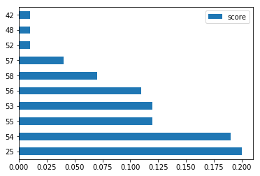

```python
import matplotlib.pyplot as plt
%matplotlib inline
plt.figure(figsize=(25,10))
imp_features.plot(kind='barh')
plt.show()
```

```python
model4.score(X_train,y_train)
```

```
0.99996160933660938
```

```python
model4.score(X_test,y_test)
```

```
0.81252878857669275
```

```python
# steps in K-fold cross validation
#1- split the dataset into K- equal parts
#2- use fold 1 as the testing set and the union of other folds as training set
#3- calculate testing accuracy
#4- repeat step 2 and 3
#5- use the average testing accuracy as the estimate of the out of the sample accuracy
```

```python
from sklearn.model_selection import train_test_split, KFold, cross_val_score
```

```python
kf = KFold(n_splits=10,shuffle=False)
```

```python
kf
```

```
KFold(n_splits=10, random_state=None, shuffle=False)
```

```python
k_range = list(range(1,15))
k_scores = []
for k in k_range:
    dt3 = tree.DecisionTreeClassifier()
    scores = cross_val_score(dt3,X_train,y_train,cv=5,scoring='accuracy')
    k_scores.append(scores.mean())
print(k_scores)
```

```
[0.81484180819480834, 0.81361332022053967, 0.81311449362888466, 0.81353666270064851, 0.81503405629338554, 0.81299913150464143, 0.81407416441866276, 0.81342152166135018, 0.81322936936624901, 0.81564809024982243, 0.81480353839084807, 0.8134213890103833, 0.81388211529653576, 0.81288403468233228]
```

```python
np.mean(k_scores)
```

```
0.81389312111564949
```

```python
np.std(k_scores)
```

```
0.00083057650829732477
```

```python
import matplotlib.pyplot as plt
%matplotlib inline
```

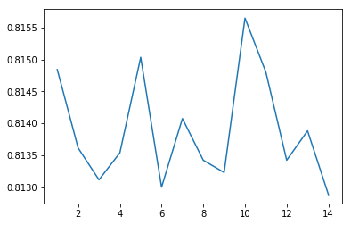

```python
# plot
plt.plot(k_range,k_scores)
```

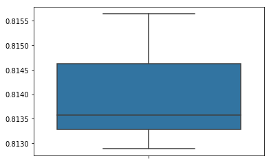

```python
import seaborn as sns
sns.boxplot(y=k_scores)
```

```python
np.round(np.sqrt(59),0)
```

```
8.0
```

```python
YPred = model4.predict(X_test)
```

```python
from sklearn.metrics import confusion_matrix,classification_report
print(confusion_matrix(YPred,y_test))
print(classification_report(YPred,y_test))
```

```
[[4334  570]
 [ 651  958]]
             precision    recall  f1-score   support

      <=50K       0.87      0.88      0.88      4904
       >50K       0.63      0.60      0.61      1609

avg / total       0.81      0.81      0.81      6513
```

```python
# what is the problem with model4:
# biased model as it looks at 6 important features and because it is a single decision tree
# other least important features are not getting a place in the tree construction process

# to remove this bias from the model we can procees with a random forest classifier
# because the RF model strikes a right balance between the bias and variance

# this is done by including the random features and many trees
```

```python
import sklearn.ensemble as ske
```

```python
################Random Forest Model########################

rf1 = ske.RandomForestClassifier(n_estimators=500, max_features=6).fit(X_train,y_train)
rf1
```

```
RandomForestClassifier(bootstrap=True, class_weight=None, criterion='gini',
            max_depth=None, max_features=6, max_leaf_nodes=None,
            min_impurity_decrease=0.0, min_impurity_split=None,
            min_samples_leaf=1, min_samples_split=2,
            min_weight_fraction_leaf=0.0, n_estimators=500, n_jobs=1,
            oob_score=False, random_state=None, verbose=0,
            warm_start=False)
```

```python
#help(ske.RandomForestClassifier())
```

```python
YTestProb = rf1.predict_proba(X_test)
YPred = rf1.predict(X_test)
```

```python
from sklearn.metrics import confusion_matrix,classification_report
print(confusion_matrix(YPred,y_test))
print(classification_report(YPred,y_test))
```

```
[[4618  604]
 [ 367  924]]
             precision    recall  f1-score   support

      <=50K       0.93      0.88      0.90      5222
       >50K       0.60      0.72      0.66      1291

avg / total       0.86      0.85      0.86      6513
```

```python
YTestProb = rf1.predict_proba(X_test)
YPred = rf1.predict(X_test)
```

```python
from sklearn.metrics import confusion_matrix,classification_report
print(confusion_matrix(YPred,y_test))
print(classification_report(YPred,y_test))
```

```
[[4618  604]
 [ 367  924]]
             precision    recall  f1-score   support

      <=50K       0.93      0.88      0.90      5222
       >50K       0.60      0.72      0.66      1291

avg / total       0.86      0.85      0.86      6513
```

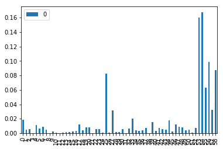

```python
plt.figure(figsize=(19,10))
pd.DataFrame(rf1.feature_importances_).plot(kind='bar')
plt.show()
```

```python
param_grid = {'criterion':['gini','entropy'],
             'max_depth': [2, 5, 7],
             'n_estimators':[100,200,300],
             'max_features': [4,6,8]
             }
```

```python
cvRF = ske.RandomForestClassifier()
```

```python
cvRF_Param = GridSearch_BestParam(X_train,y_train,cvRF, param_grid,cv=10)
```

```
E:\New folder\lib\site-packages\sklearn\model_selection\_search.py:761: DeprecationWarning: The grid_scores_ attribute was deprecated in version 0.18 in favor of the more elaborate cv_results_ attribute. The grid_scores_ attribute will not be available from 0.20
  DeprecationWarning)
```

```python
cvRF_Param
```

```
[mean: 0.75818, std: 0.00090, params: {'criterion': 'gini', 'max_depth': 2, 'max_features': 4, 'n_estimators': 100},
 mean: 0.75768, std: 0.00017, params: {'criterion': 'gini', 'max_depth': 2, 'max_features': 4, 'n_estimators': 200},
 mean: 0.75772, std: 0.00020, params: {'criterion': 'gini', 'max_depth': 2, 'max_features': 4, 'n_estimators': 300},
 mean: 0.76866, std: 0.00885, params: {'criterion': 'gini', 'max_depth': 2, 'max_features': 6, 'n_estimators': 100},
 mean: 0.76705, std: 0.00378, params: {'criterion': 'gini', 'max_depth': 2, 'max_features': 6, 'n_estimators': 200},
 mean: 0.76873, std: 0.00407, params: {'criterion': 'gini', 'max_depth': 2, 'max_features': 6, 'n_estimators': 300},
 mean: 0.78087, std: 0.00411, params: {'criterion': 'gini', 'max_depth': 2, 'max_features': 8, 'n_estimators': 100},
 mean: 0.77914, std: 0.00543, params: {'criterion': 'gini', 'max_depth': 2, 'max_features': 8, 'n_estimators': 200},
 mean: 0.77879, std: 0.00430, params: {'criterion': 'gini', 'max_depth': 2, 'max_features': 8, 'n_estimators': 300},
 mean: 0.81906, std: 0.00527, params: {'criterion': 'gini', 'max_depth': 5, 'max_features': 4, 'n_estimators': 100},
 mean: 0.81761, std: 0.00458, params: {'criterion': 'gini', 'max_depth': 5, 'max_features': 4, 'n_estimators': 200},
 mean: 0.81730, std: 0.00442, params: {'criterion': 'gini', 'max_depth': 5, 'max_features': 4, 'n_estimators': 300},
 mean: 0.84164, std: 0.00636, params: {'criterion': 'gini', 'max_depth': 5, 'max_features': 6, 'n_estimators': 100},
 mean: 0.84145, std: 0.00578, params: {'criterion': 'gini', 'max_depth': 5, 'max_features': 6, 'n_estimators': 200},
 mean: 0.84202, std: 0.00600, params: {'criterion': 'gini', 'max_depth': 5, 'max_features': 6, 'n_estimators': 300},
 mean: 0.84686, std: 0.00690, params: {'criterion': 'gini', 'max_depth': 5, 'max_features': 8, 'n_estimators': 100},
 mean: 0.84747, std: 0.00762, params: {'criterion': 'gini', 'max_depth': 5, 'max_features': 8, 'n_estimators': 200},
 mean: 0.84755, std: 0.00845, params: {'criterion': 'gini', 'max_depth': 5, 'max_features': 8, 'n_estimators': 300},
 mean: 0.84325, std: 0.00650, params: {'criterion': 'gini', 'max_depth': 7, 'max_features': 4, 'n_estimators': 100},
 mean: 0.84321, std: 0.00762, params: {'criterion': 'gini', 'max_depth': 7, 'max_features': 4, 'n_estimators': 200},
 mean: 0.84394, std: 0.00594, params: {'criterion': 'gini', 'max_depth': 7, 'max_features': 4, 'n_estimators': 300},
 mean: 0.85097, std: 0.00911, params: {'criterion': 'gini', 'max_depth': 7, 'max_features': 6, 'n_estimators': 100},
 mean: 0.85174, std: 0.00868, params: {'criterion': 'gini', 'max_depth': 7, 'max_features': 6, 'n_estimators': 200},
 mean: 0.85039, std: 0.00843, params: {'criterion': 'gini', 'max_depth': 7, 'max_features': 6, 'n_estimators': 300},
 mean: 0.85197, std: 0.01003, params: {'criterion': 'gini', 'max_depth': 7, 'max_features': 8, 'n_estimators': 100},
 mean: 0.85254, std: 0.01001, params: {'criterion': 'gini', 'max_depth': 7, 'max_features': 8, 'n_estimators': 200},
 mean: 0.85308, std: 0.00901, params: {'criterion': 'gini', 'max_depth': 7, 'max_features': 8, 'n_estimators': 300},
 mean: 0.75960, std: 0.00376, params: {'criterion': 'entropy', 'max_depth': 2, 'max_features': 4, 'n_estimators': 100},
 mean: 0.75764, std: 0.00011, params: {'criterion': 'entropy', 'max_depth': 2, 'max_features': 4, 'n_estimators': 200},
 mean: 0.75764, std: 0.00011, params: {'criterion': 'entropy', 'max_depth': 2, 'max_features': 4, 'n_estimators': 300},
 mean: 0.76516, std: 0.00556, params: {'criterion': 'entropy', 'max_depth': 2, 'max_features': 6, 'n_estimators': 100},
 mean: 0.77008, std: 0.00532, params: {'criterion': 'entropy', 'max_depth': 2, 'max_features': 6, 'n_estimators': 200},
 mean: 0.76620, std: 0.00527, params: {'criterion': 'entropy', 'max_depth': 2, 'max_features': 6, 'n_estimators': 300},
 mean: 0.77806, std: 0.00538, params: {'criterion': 'entropy', 'max_depth': 2, 'max_features': 8, 'n_estimators': 100},
 mean: 0.77772, std: 0.00399, params: {'criterion': 'entropy', 'max_depth': 2, 'max_features': 8, 'n_estimators': 200},
 mean: 0.77607, std: 0.00283, params: {'criterion': 'entropy', 'max_depth': 2, 'max_features': 8, 'n_estimators': 300},
```

[output cut: 18 more lines]

```python
paramCV = sorted(cvRF_Param,key=itemgetter(1), reverse=True)
```

```python
paramCV = paramCV[0].parameters
```

```python
paramCV
```

```
{'criterion': 'entropy',
 'max_depth': 7,
 'max_features': 8,
 'n_estimators': 200}
```

```python
cvRF = ske.RandomForestClassifier(n_estimators=paramCV["n_estimators"],
                                  criterion=paramCV["criterion"],
                                  max_depth=paramCV["max_depth"],
                                  max_features=paramCV["max_features"]
                                )

cvRF.fit(X_train,y_train)
```

```
RandomForestClassifier(bootstrap=True, class_weight=None, criterion='entropy',
            max_depth=7, max_features=8, max_leaf_nodes=None,
            min_impurity_decrease=0.0, min_impurity_split=None,
            min_samples_leaf=1, min_samples_split=2,
            min_weight_fraction_leaf=0.0, n_estimators=200, n_jobs=1,
            oob_score=False, random_state=None, verbose=0,
            warm_start=False)
```

```python
YValidRF = cvRF.predict(X_test)

print (confusion_matrix(y_test,YValidRF))
```

```
[[4765  220]
 [ 765  763]]
```

```python
cvRF.score(X_train,y_train)
```

```
0.8529253685503686
```

```python
cvRF.score(X_test,y_test)
```

```
0.84876401044065719
```

```python
cvRF.feature_importances_
```

```
array([  3.01197849e-02,   7.92461653e-04,   5.39310954e-04,
         0.00000000e+00,   1.01546997e-03,   2.63854694e-03,
         1.37654127e-03,   3.70859225e-04,   0.00000000e+00,
         1.80476278e-03,   4.71239876e-05,   1.26379151e-04,
         1.13466742e-04,   1.24194723e-03,   4.36563525e-04,
         2.84362470e-04,   3.08059669e-04,   1.63859839e-02,
         3.46530622e-03,   9.52459142e-03,   8.07415482e-03,
         9.35960055e-06,   4.81246064e-03,   1.58703595e-03,
         2.55385796e-04,   1.97978481e-01,   3.48485712e-04,
         1.12830794e-01,   1.43444753e-03,   1.03334068e-03,
         1.54382483e-03,   2.35374803e-07,   6.26800326e-04,
         2.32806738e-02,   1.45548648e-03,   8.99470084e-04,
         1.19451540e-03,   1.17693548e-02,   2.58386910e-05,
         2.03119286e-02,   4.18432014e-04,   4.54385465e-04,
         7.18104894e-04,   4.03134756e-04,   4.18739951e-02,
         1.74435362e-03,   4.14617344e-02,   1.81829359e-02,
         9.76988888e-03,   5.14825909e-04,   7.79048376e-04,
         9.33285910e-05,   1.19320486e-03,   8.38096136e-02,
         4.09923278e-03,   1.07523343e-01,   1.63544996e-01,
         2.44556889e-02,   3.88961569e-02])
```

```python
imp_RF = pd.Series(np.round(cvRF.feature_importances_,2))
```

```python
feat_imp['score_rf'] = imp_RF
```

```python
feat_imp.sort_values(by='score_rf', ascending=False).head(10)
```

|  | var | score | score_rf |
| --- | --- | --- | --- |
| 25 | marital_status_ Married-civ-spouse | 0.20 | 0.20 |
| 56 | capital_gain | 0.11 | 0.16 |
| 55 | education_num | 0.12 | 0.11 |
| 27 | marital_status_ Never-married | 0.00 | 0.11 |
| 53 | age | 0.12 | 0.08 |
| 58 | hours_per_week | 0.07 | 0.04 |
| 46 | relationship_ Own-child | 0.00 | 0.04 |
| 44 | relationship_ Not-in-family | 0.00 | 0.04 |
| 0 | sex_ Male | 0.01 | 0.03 |
| 57 | capital_loss | 0.04 | 0.02 |

```python
feat_imp.sort_values(by='score_rf', ascending=False).tail(10)
```

|  | var | score | score_rf |
| --- | --- | --- | --- |
| 24 | marital_status_ Married-AF-spouse | 0.00 | 0.0 |
| 8 | workclass_ Without-pay | 0.00 | 0.0 |
| 26 | marital_status_ Married-spouse-absent | 0.00 | 0.0 |
| 7 | workclass_ State-gov | 0.00 | 0.0 |
| 28 | marital_status_ Separated | 0.00 | 0.0 |
| 1 | workclass_ Federal-gov | 0.01 | 0.0 |
| 30 | occupation_ Adm-clerical | 0.01 | 0.0 |
| 31 | occupation_ Armed-Forces | 0.00 | 0.0 |
| 32 | occupation_ Craft-repair | 0.01 | 0.0 |
| 29 | marital_status_ Widowed | 0.00 | 0.0 |

```python
len(np.where(cvRF.feature_importances_<0.01)[0])
```

```
44
```

```python
var_list = feat_imp[feat_imp.score_rf<0.01]
```

```python
var_list.columns = ['variables', 'score', 'score_rf']
```

```python
var_list.shape
```

```
(41, 3)
```

```python
set(var_list.variables)
```

```
{'education_ 11th',
 'education_ 12th',
 'education_ 1st-4th',
 'education_ 5th-6th',
 'education_ 7th-8th',
 'education_ 9th',
 'education_ Assoc-acdm',
 'education_ Assoc-voc',
 'education_ Doctorate',
 'education_ Preschool',
 'education_ Prof-school',
 'education_ Some-college',
 'fnlwgt',
 'marital_status_ Married-AF-spouse',
 'marital_status_ Married-spouse-absent',
 'marital_status_ Separated',
 'marital_status_ Widowed',
 'occupation_ Adm-clerical',
 'occupation_ Armed-Forces',
 'occupation_ Craft-repair',
 'occupation_ Farming-fishing',
 'occupation_ Handlers-cleaners',
 'occupation_ Machine-op-inspct',
 'occupation_ Priv-house-serv',
 'occupation_ Protective-serv',
 'occupation_ Sales',
 'occupation_ Tech-support',
 'occupation_ Transport-moving',
 'race_ Asian-Pac-Islander',
 'race_ Black',
 'race_ Other',
 'race_ White',
 'relationship_ Other-relative',
 'workclass_ Federal-gov',
 'workclass_ Local-gov',
 'workclass_ Never-worked',
 'workclass_ Private',
 'workclass_ Self-emp-inc',
 'workclass_ Self-emp-not-inc',
 'workclass_ State-gov',
 'workclass_ Without-pay'}
```

```python
cdata_new = cdata[['education_ 11th',
 'education_ 12th',
 'education_ 1st-4th',
 'education_ 5th-6th',
 'education_ 7th-8th',
 'education_ 9th',
 'education_ Assoc-acdm',
 'education_ Assoc-voc',
 'education_ Doctorate',
 'education_ Preschool',
 'education_ Prof-school',
 'education_ Some-college',
 'fnlwgt',
 'marital_status_ Married-AF-spouse',
 'marital_status_ Married-spouse-absent',
 'marital_status_ Separated',
 'marital_status_ Widowed',
 'occupation_ Adm-clerical',
 'occupation_ Armed-Forces',
 'occupation_ Craft-repair',
 'occupation_ Farming-fishing',
 'occupation_ Handlers-cleaners',
 'occupation_ Machine-op-inspct',
 'occupation_ Priv-house-serv',
 'occupation_ Protective-serv',
 'occupation_ Sales',
 'occupation_ Tech-support',
 'occupation_ Transport-moving',
 'race_ Asian-Pac-Islander',
 'race_ Black',
 'race_ Other',
 'race_ White',
 'relationship_ Other-relative',
 'workclass_ Federal-gov',
 'workclass_ Local-gov',
 'workclass_ Never-worked',
 'workclass_ Private',
 'workclass_ Self-emp-inc',
 'workclass_ Self-emp-not-inc',
 'workclass_ State-gov',
 'workclass_ Without-pay']]
```

```python
cdata_new.columns
```

```
Index(['education_ 11th', 'education_ 12th', 'education_ 1st-4th',
       'education_ 5th-6th', 'education_ 7th-8th', 'education_ 9th',
       'education_ Assoc-acdm', 'education_ Assoc-voc', 'education_ Doctorate',
       'education_ Preschool', 'education_ Prof-school',
       'education_ Some-college', 'fnlwgt',
       'marital_status_ Married-AF-spouse',
       'marital_status_ Married-spouse-absent', 'marital_status_ Separated',
       'marital_status_ Widowed', 'occupation_ Adm-clerical',
       'occupation_ Armed-Forces', 'occupation_ Craft-repair',
       'occupation_ Farming-fishing', 'occupation_ Handlers-cleaners',
       'occupation_ Machine-op-inspct', 'occupation_ Priv-house-serv',
       'occupation_ Protective-serv', 'occupation_ Sales',
       'occupation_ Tech-support', 'occupation_ Transport-moving',
       'race_ Asian-Pac-Islander', 'race_ Black', 'race_ Other', 'race_ White',
       'relationship_ Other-relative', 'workclass_ Federal-gov',
       'workclass_ Local-gov', 'workclass_ Never-worked', 'workclass_ Private',
       'workclass_ Self-emp-inc', 'workclass_ Self-emp-not-inc',
       'workclass_ State-gov', 'workclass_ Without-pay'],
      dtype='object')
```

```python
X_train1, X_test1, y_train1,y_test1 = train_test_split(cdata_new,target,test_size=0.20,random_state=1234)
```

```python
X_train1.shape, X_test1.shape, y_train1.shape,y_test1.shape
```

```
((26048, 41), (6513, 41), (26048,), (6513,))
```

```python
dt3.fit(X_train1,y_train1)
```

```
DecisionTreeClassifier(class_weight=None, criterion='gini', max_depth=None,
            max_features=None, max_leaf_nodes=None,
            min_impurity_decrease=0.0, min_impurity_split=None,
            min_samples_leaf=1, min_samples_split=2,
            min_weight_fraction_leaf=0.0, presort=False, random_state=None,
            splitter='best')
```

```python
dt3.score(X_train1,y_train1)
```

```
0.99212991400491402
```

```python
dt3.score(X_test1,y_test1)
```

```
0.69660678642714569
```

```python
cvRF.fit(X_train1,y_train1)
```

```
RandomForestClassifier(bootstrap=True, class_weight=None, criterion='entropy',
            max_depth=7, max_features=8, max_leaf_nodes=None,
            min_impurity_decrease=0.0, min_impurity_split=None,
            min_samples_leaf=1, min_samples_split=2,
            min_weight_fraction_leaf=0.0, n_estimators=200, n_jobs=1,
            oob_score=False, random_state=None, verbose=0,
            warm_start=False)
```

```python
cvRF.score(X_train1,y_train1)
```

```
0.77533783783783783
```

```python
cvRF.score(X_test1,y_test1)
```

```
0.77736834024259172
```

```python
imp_RF_reducedset = pd.Series(np.round(cvRF.feature_importances_,2))
```

```python
feat_imp['score_rf_reducedset'] = imp_RF_reducedset
```

```python
feat_imp.sort_values(by='score_rf_reducedset', ascending=False).head(10)
```

|  | var | score | score_rf | score_rf_reducedset |
| --- | --- | --- | --- | --- |
| 10 | education_ 12th | 0.00 | 0.00 | 0.19 |
| 37 | occupation_ Other-service | 0.00 | 0.01 | 0.13 |
| 8 | workclass_ Without-pay | 0.00 | 0.00 | 0.12 |
| 0 | sex_ Male | 0.01 | 0.03 | 0.07 |
| 17 | education_ Bachelors | 0.00 | 0.02 | 0.07 |
| 21 | education_ Preschool | 0.00 | 0.00 | 0.07 |
| 32 | occupation_ Craft-repair | 0.01 | 0.00 | 0.06 |
| 29 | marital_status_ Widowed | 0.00 | 0.00 | 0.04 |
| 12 | education_ 5th-6th | 0.00 | 0.00 | 0.04 |
| 15 | education_ Assoc-acdm | 0.00 | 0.00 | 0.04 |

# Solution?

```python
# Boosting Models
```

```python
# 1. Gradient Boosting Model
# 2. Xtreme Gradient Boosting
# 3. Stochastic Gradient Boosting
```